# What makes a book successful?

## Metro College of Technology

### November, 2021

### Ana Clara Tupinambá Freitas, oriented by Professor Vijay Kumar

Since the creation of the Gutenberg press the numbers of writers and readers have increased. Change of power, revolution and peace have been influenced by words. The internet eased this process and sharing a book has never been easier.

This study has the objective of trying to find what factors make a successful book and provide a recommendation engine to publishers.

Attributes of final data model are:

```
- Year Of Publication: which year the book being evaluated has been publish
- Series?: Is the book part of a Serie
- 1st Publication Era: when has the book have first been published?
- Awards?: Has the book received an award?
- Genre1 - First level of genre:
    - Non-Fiction
    - Fiction
- Genre2 - Second level of genre:
    - Classics
    - Historical
    - Thriller
    - Biography
    - Contemporary
    - Fantasy
    - Others
- User Country:
    - USA
    - Other COuntries
- Group Age:
    - Child/Teenager (Age <= 19)
    - Young Adult (< 39)
    - Adult/Senior (> 39)
- Successful?
    - Successful(Rating >= 8)
    - Regular
```

Target: **Successful?**

**The final dataset is a combined one to get features as user location and genre together** as showed in the figure below.

Data sources:

- Rating, Location, Age and other attributes: http://www2.informatik.uni-freiburg.de/~cziegler/BX/
- Genre, Setting, and other attributes: https://zenodo.org/record/4265096#.YXlibBwpCHs

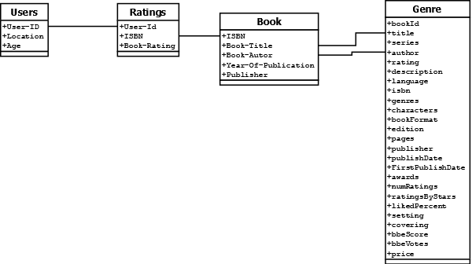

# Importing Packages

```python
import os
import pandas as pd
import numpy as np
import  re
import datetime

import matplotlib.pyplot as plt
import seaborn as sns
from statsmodels.graphics.gofplots import qqplot

from scipy.stats import kstest
import researchpy as rp
from scipy.stats import mannwhitneyu
from scipy.stats import levene
from scipy.stats import kruskal
from scipy.stats import f_oneway

from scipy.stats.contingency import chi2_contingency

from sklearn.model_selection import train_test_split
from sklearn.preprocessing import StandardScaler

# from statsmodels.stats.outliers_influence import variance_inflation_factor
from sklearn.model_selection import cross_val_score, GridSearchCV


from sklearn import  metrics
from sklearn.metrics import confusion_matrix, classification_report
from sklearn.metrics import roc_auc_score, roc_curve

from sklearn.linear_model import LogisticRegression
from sklearn import datasets,neighbors
from sklearn import datasets, svm, metrics
from sklearn.linear_model import SGDClassifier
from sklearn.ensemble import AdaBoostClassifier
from sklearn.ensemble import RandomForestClassifier
from sklearn.neural_network import MLPClassifier
from sklearn.tree import DecisionTreeClassifier,plot_tree

import warnings
```

# User Defined Functions

## General

```python
def chck_miss(df):

    Total = df.isnull().count().sort_values(ascending=True)
    Missing = df.isnull().sum().sort_values(ascending=True)

    Percentage_Miss = round((Missing/Total)*100,2)

    Summary = pd.concat([Total,Missing, Percentage_Miss],axis=1,keys=['Total','# Missing','% Missing'],sort=True)

    print('Are there any missing value?')
    print(Summary)

    del Total, Missing, Percentage_Miss, Summary
```

## Univariate Categorical:

```python
#reset graphs settings
sns.reset_orig()
```

```python
def uni_categorical(df,# data frame, if variable inform as df[[var]]
                    size=None,# size of the plot to be create: "L" large,otherwise Small
                    label=None, #if the bar plot should have labels and ticks
                    ref=None, # ref add a y-axis reference line inform value
                   ):
    '''This function returns summarization and visual for univariate analysis of categorical features of a dataset'''
    print('############### Univariate analysis - Categorical ###############')
# Setting canvas
    sns.color_palette("dark")    #, as_cmap=True
    sns.set_context("talk", font_scale=0.8) #paper, notebook, talk, poster

    #extracting only non-numerical features
    df = df.select_dtypes(exclude=np.number)
    for i in df.columns:
     #   if type(df.loc[0, i]) == str: #checking type of features
# Summarization
            d1 = df[i].value_counts(dropna=False)
            d2 = round(df[i].value_counts(normalize=True,dropna=False)*100, 2)
            d3 = pd.concat([d1, d2], axis=1)
            d3.columns = ['Count', 'Percentage']
            print('\nThis is univariate analysis for', "'", i, "'", '\n', d3)

 # Visualization
            d1 = pd.DataFrame(d1).T
            d1 = pd.melt(d1,var_name=str(i),value_vars=d1)
            d1[i]=d1[i].fillna('Missing')
            fig, ax = plt.subplots()
            if size == 'L':
                fig.set_size_inches(22, 10)
            else:
                fig.set_size_inches(8, 8)
            plot1=sns.barplot(y=d1['value'],x=d1[i], data=d1)#,color='darkblue'
            if label == 'Y':
                for p in ax.patches:
                    ax.annotate(int(p.get_height()),
                    (p.get_x()+p.get_width()/2+.3, p.get_height()),
                    ha='center',va='center',xytext=(2, 10),textcoords='offset points', rotation=45)
            else:
                plt.tick_params(
                    axis='x',          # changes apply to the x-axis
                    which='both',      # both major and minor ticks are affected,'major', 'minor', 'both'
                    bottom=False,      # ticks along the bottom edge are off
                    top=False,         # ticks along the top edge are off
                    labelbottom=False) # labels along the bottom edge are off
            plt.xticks(rotation=45, ha='right')
            if ref != None:
                plot1.axhline(ref,c='red',label='threshold='+str(ref),linestyle='--')
                plt.legend(loc=1)
            ax.set_title('Univariate plot')
            plt.show()
    print('\n\n')
```

## Univariate Numerical:

```python
def uni_numerical(df):
    '''This function returns summarization and visual for univariate analysis of numerical features of a dataset'''

# Setting canvas
    sns.color_palette("dark")    #, as_cmap=True
    sns.set_context("talk", font_scale=1) #paper, notebook, talk, poster

# Summarization
    print('############### Univariate analysis - Numerical ###############')
    df.describe()
    Summary = dict(df.describe())
    for i in Summary:
        Summary[i]['count'] = df[i].count()
        Summary[i]['variance'] = df[i].var()
        Summary[i]['IQR'] = Summary[i]['75%'] - Summary[i]['25%']
        Summary[i]['range'] = Summary[i]['max'] - Summary[i]['min']
        Summary[i]['skewness'] = df[i].skew()
        Summary[i]['kurtosis'] = df[i].kurtosis()
        Summary[i]['mode'] = df[i].mode() #axis='columns'
#    print(Summary)
        print('\nThis is univariate analysis for',"'", i, "'", '\n', Summary[i])
# Visualization
        # Histogram and Boxplot
        f, (ax_box, ax_hist) = plt.subplots(2, sharex=True, gridspec_kw={"height_ratios": (.12, .88)})
        f.set_size_inches(12, 8)
#         sns.distplot(a=df[i], hist=True, kde=True, rug=True, ax=ax_hist)
        sns.histplot(x=df[i], kde=True, ax=ax_hist)
        sns.boxplot(x=df[i], ax=ax_box)
        ax_box.set_title('Univariate plot')
        ax_box.set(xlabel='')
        plt.show()
# normality test
#        stat, p_normal = shapiro(df[i])
        stat, p_normal = kstest(df[i],'norm')
        print('Kolmogorov\'s Statistics=%.3f, p=%.3f' % (stat, p_normal))
# interpretation
        alpha = 0.05
        if p_normal > alpha:
            print('Normality\'s test result: Sample looks Gaussian (fail to reject H0)')
        else:
            print('Normality\'s test result: Sample does not look Gaussian (reject H0)')
```

## Bivariate Categorical features x Categorical target:

```python
def bi_categorical_cat(df_var_pred, df_var_target,size):
    '''This function returns summarization, visual,and test of independency for bivariate analysis of categorical x categorical features. df[var_pred], df[var_target]'''
# Setting canvas
    sns.color_palette("dark")    #, as_cmap=True
    sns.set_context("talk", font_scale=0.8) #paper, notebook, talk, poster


    contigency_table = pd.crosstab(df_var_pred,df_var_target)

    print('This is contingency table for:\n\n',contigency_table,'\n')

    alpha = 0.05
    chi_2, p_val, dof, exp_val = chi2_contingency(contigency_table)
    if size == 'L':
        contigency_table.plot(kind='bar',figsize=(15,6))
    else:
        contigency_table.plot(kind='bar',figsize=(8,3))
    plt.title('Bivariate Analysis: ' + str(df_var_target.name) +' vs ' + str(df_var_pred.name))
#     plt.ylim(0,3500)
    plt.legend(ncol=2,fontsize=10)
    plt.show()

    print('\nChi-square\'s Null hypothesis: There\'s no correlation between variables.')
    print("\nChi-square's results:")
    if p_val > alpha:
        print('DOF: ',dof,'\np-value= ',p_val,"\n Fail to reject Null Hypothesis. There's no correlation between variables at 5% significance level.")
    else:
        print('DOF: ',dof,'\np-value= ',p_val,"\n\nReject Null Hypothesis. There's some correlation between variables at 5% significance level.")
```

## Bivariate Numerical features x Categorical target:

```python
def bi_categorical_cont(df,var_target,size):
    '''This function returns summarization, visual, and test of independency for bivariate analysis of continuous target x categorical  features,taking a continuous variable as the target.  '''

    print('############### Bivariate analysis - Categorical x Numerical ###############')
    print('\n*If Categorical has 2 levels: Mann-Whitney U test, if more: One-way ANOVA/Kruskal H test')

# Setting canvas
    sns.color_palette("dark")    #, as_cmap=True
    sns.set_context("talk", font_scale=1.5) #paper, notebook, talk, poster

# Defining alpha:
    alpha = 0.05
# Verifying datatypes extract only numerics
    df_num = df.select_dtypes(include=np.number)


# If target is numeric:
    if var_target in df_num.columns:
        df_cat = df.select_dtypes(exclude=np.number)
        for i in df_cat.columns:
            if i != var_target:
                vis = pd.crosstab(df[var_target],df[i], margins = False)
                tab = rp.summary_cont(df[var_target].groupby(df[i]),decimals=3)#conf=0.95
#                print(tab)
# verifying if there's missing values and dropping them for testing
                if sum(df[num].isnull()) != 0:
                    print("There's",sum(df[num].isnull()),"missing values that were dropped just to perform test.\n" )
                    df.dropna(inplace=True)
                result = df.groupby(i)[var_target].apply(list)
#                print('Result:',result)
# Printing Assumptions:
                if len(result.index) == 2:
                    print('\nThis is Mann-Whitney U test for' , var_target, 'and',i )
                    print('\nMann-Whitney U test:\n Null hypothesis: The distribution of scores for the two groups are equal.\n Assumptions:\n 1.Dependent variable that is measured at the continuous or ordinal level.\n 2.Groups are independent of one another. \n 3.What\'s the shape of each group distribution.\n\t a) Similar shapes: \n\t\t Alternative hypothesis: the medians of the two groups are not equal.\n\t b) Different shapes:\n\t\t Alternative hypothesis: the distribution of scores for the two groups are not equal.')
                    print('\nSummary:')
                    print(tab)
# Visualization
                    sns.set_palette("dark") # colorblind   pastel
                    sns.set(style="white") # whitegrid ticks
                    fig, ax = plt.subplots()
                    fig.set_size_inches(12, 4)
                    sns.boxplot(x=df[i],y=df[var_target], data=df)
                    sns.stripplot(x=df[i],y=df[var_target], data=df,
              size=4, color=".3", linewidth=0)
                    plt.xticks(rotation=45, ha='right')
                    ax.set_title('Bivariate plot: ' + var_target + ' and ' + i)
                    plt.show()
                    l = pd.melt(vis,var_name=str(i),value_vars=vis)

                else:
# ANOVA
# Printing Assumptions:
                    print('\nThis is ANOVA/Kruskal for' , var_target, 'and',i,'\n' )
                    print('One-way ANOVA Assumptions\n In order to run a one-way ANOVA the following assumptions must be met:\n 1.The response of interest is continuous and normally distributed for each treatment group.\n \tCLT :\n \t\tIf looks normal each group must have more than 30 observations – no need for Normality’s test;\n \t\tIf moderately skewed(|0.5| < skewness < |1.0|), each group must have more than 100 observations – no need for Normality’s test;\n\t*If not normal, proceed to Kruskal test.\n 2.Treatment groups are independent of one another. \n 3.There are no major outliers.\n 4.A check for unequal variances will help determine which version of a one-way ANOVA is most appropriate (Levene’s test, Null hypothesis: variances are equal between groups):\n \tA .If variances are equal, then the assumptions of a standard one-way ANOVA are met.\n \tB. If variances are unequal, then a Kruskal’s test is appropriate.\n\n*Kruskal\'s Null hypothesis: H0: the group populations have equal dominance; i.e. when one element is drawn at random from each group population, the largest (or smallest, or second smallest, etc.) element is equally likely to come from any one of the group populations or H0: the group population medians are equal(if groups distributions have the same shape) ')
                    print('\nSummary:')
                    print(tab)
# Visualization
                    sns.set_palette("dark") # colorblind   pastel
                    sns.set(style="white") # whitegrid ticks
                    fig, ax = plt.subplots()
                    if size == 'L':
                        fig.set_size_inches(50, 4)
                    else:
                        fig.set_size_inches(12, 4)
                    sns.set_context("paper", font_scale=1.2)
                    sns.boxplot(x=df[i],y=df[var_target], data=df)
                    sns.stripplot(x=df[i],y=df[var_target], data=df,
              size=4, color=".3", linewidth=0)
                    plt.xticks(rotation=45, ha='right',fontsize=12)
                    ax.set_title('Bivariate plot: ' + var_target + ' and ' + i)
                    plt.show()
                    l = pd.melt(vis,var_name=str(i),value_vars=vis)
                    l = pd.DataFrame(l)

            if len(result.index) == 2:
#T-test
                stat_l, p_lev = levene(*result)
                print('\nLevene\'s Null hypothesis: Equal variance')
                print('\nLevene\'s Statistics=%.3f, p=%.3f' % (stat_l, p_lev))
                if p_lev  > alpha:#Equal varinaces
                    stat_u, p_u = mannwhitneyu(*result)
                    print('Levene\'s test result: Equal variances (fail to reject H0)')
                    print('\nMann-Whitney U \'s Null hypothesis: The distribution of scores for the two groups are equal.')
                    print('\nMann-Whitney U \'s Statistics (equal variances)=%.3f, p=%.3f' % (stat_u, p_u))
# interpretation
                    if p_u > alpha:
                        print('Mann-Whitney U \'s test result: There are no differences in medians, samples medians are equal. (fail to reject H0)')
                    else:
                        print('Mann-Whitney U \'s test result: The medians of the two groups are not equal. (reject H0)')

                else:#Unequal variances
                    stat_u, p_u = mannwhitneyu(*result)
                    print('Levene\'s test result: Unequal variances (reject H0)')
                    print('\nMann-Whitney U \'s Statistics (unequal variances)=%.3f, p=%.3f' % (stat_u, p_u))
# interpretation
                    if p_u > alpha:
                        print('\nMann-Whitney U \'s Null hypothesis: The distribution of scores for the two groups are equal.')
                        print('Mann-Whitney U \'s test result: The distribution of scores for the two groups are equal. (fail to reject H0)')
                    else:
                        print('\nMann-Whitney U \'s Null hypothesis: The distribution of scores for the two groups are equal.')
                        print('Mann-Whitney U \'s test result: The distribution of scores for the two groups are not equal. (reject H0)')
# ANOVA
            else:
                stat_l, p_lev = levene(*result)
                print('\nLevene\'s Null hypothesis: Equal variance')
                print('\nLevene\'s Statistics=%.3f, p=%.3f' % (stat_l, p_lev))
                p_one = np.nan
                if p_lev  > alpha: #Equal variances
                    stat_one, p_one = f_oneway(*result)
                    stat_k, p_h =  kruskal(*result)
                    print('Levene\'s test result: equal variances (reject H0)')
                    print('\nKruskal\'s Statistics(equal variances)=%.3f, p=%.3f' % (stat_k, p_h))
                    print('\nANOVA\'s Statistics(equal variances)=%.3f, p=%.3f' % (stat_one, p_one))
                    if p_one > alpha:
                        print('\nANOVA\'s Null hypothesis: There are  differences in means')
                        print('ANOVA\'s test result: There are no differences in means, samples are equal. (fail to reject H0)')
                    else:
                        print('\nANOVA\'s Null hypothesis: There are  differences in means')
                        print('ANOVA\'s test result: There are  differences in means (reject H0)')
                else: # Unequal variances
                    stat_k, p_h  = kruskal(*result)
                    print('Levene\'s test result: Unequal variances (reject H0)')
                    print('\nKruskal\'s Statistics(unequal variances)=%.3f, p=%.3f' % (stat_k, p_h))

                if p_h > alpha:
                    print('\nKruskal\'s Null hypothesis: All sample distributions are equal.')
                    print('Kruskal\'s test result: All sample distributions are equal. (fail to reject H0)')
                else:
                    print('\nKruskal\'s Null hypothesis: All sample distributions are equal.')
                    print('Kruskal\'s test result: One or more sample distributions are not equal. (reject H0)')

    print('\n\n')
```

```python
def bi_numerical_num(df):
    '''This function returns summarization, visual,and test of independency for bivariate analysis of numerical x numerical features. '''

    print('############### Bivariate analysis - Numerical x Numerical ###############')
# Printing Assumptions:
    print('\nCorrelation (how strong the correlation is):\n Null hypothesis: there’s no association between variables.\n \t1.Normal distribution for both variables for pearson;\n  \t2.homoscedasticity assumes that data is equally distributed about the regression line.\n \t3.Linear? \n \t\tLinear: pearson\n \t\tMonotonically related (not normal): spearman kendall hoeffding \n')

# Verifying datatypes extract only numerics
    df = df.select_dtypes(include=np.number)
#numerics = ['int16', 'int32', 'int64', 'float16', 'float32', 'float64']


# # correlation test
#     print('\nThis is Pearson\'s correlation:')
#     print(df.corrwith(df[var_target], method='pearson'), '\n')
#     print('This is Spearman\'s correlation:')
#     print(df.corrwith(df[var_target], method='spearman'), '\n')

# Visualization
    #Pearson
    mask = np.zeros_like(df.corr())
    mask[np.triu_indices_from(mask)] = True
    fig, ax = plt.subplots(figsize=(21,21))
    sns.set_palette("dark") # colorblind   pastel
    sns.set(style="whitegrid") #whitegrid ticks
    sns.heatmap(round(df.corr(method='pearson'),2),annot=True, annot_kws={"fontsize":11},linewidths=0.01,mask=mask)
    plt.title('Pearson correlation')
    plt.show()
```

#### Setting warnings OFF/ON

```python
warnings.filterwarnings('ignore')#'always'
```

# Loading Data Frame

## First look at the dataset:

[figure not shown]

**ISBN have** a pattern as shown above,but number of digits in each group can vary. For this dataset, the groups listed are not separated by hyphen or space, making **its use unreliable**.

Source: https://en.wikipedia.org/wiki/International_Standard_Book_Number

```python
# Changing Directory
os.chdir(r'D:\1_Metro College\Courses\DSP-Python\Project Personal\Data')

df_books_o = pd.read_csv('BX-Books.csv',delimiter=';', quotechar='"',escapechar='\\' , encoding='ISO-8859-1')#latin-1
df_genre = pd.read_csv('books_1.Best_Books_Ever.csv',on_bad_lines='warn')
df_ratings = pd.read_csv('BX-Book-Ratings.csv',delimiter=';', quotechar='"',escapechar='\\' , encoding='ISO-8859-1')
df_users = pd.read_csv('BX-Users.csv',delimiter=';', quotechar='"',escapechar='\\' , encoding='ISO-8859-1')

print('Shape of books dataset: ',df_books_o.shape)
print('Shape of genre dataset: ',df_genre.shape)
print('Shape of ratings dataset: ',df_ratings.shape)


#As mentioned before ISBN is unreliable, so the join will be made by Book Title and Author
df_f = df_books_o.merge(df_genre,left_on=['Book-Title','Book-Author'], right_on=['title','author'])

# Just a selection of genre dataset will be maintained as just some of them can be generalized for the book, and others may depend on the edition evaluated.
df_books = df_f.loc[:,['ISBN', 'Book-Title', 'Book-Author', 'Year-Of-Publication', 'Publisher','series','genres','characters','setting','firstPublishDate','awards']]

df_books = df_books.merge(df_ratings,on='ISBN')

df_books = df_books.merge(df_users,on='User-ID')

print('\nShape of books dataset after joining: ',df_books.shape)
```

```
Shape of books dataset:  (271379, 8)
Shape of genre dataset:  (52478, 25)
Shape of ratings dataset:  (1149780, 3)

Shape of books dataset after joining:  (80745, 15)
```

# Looking at the combined dataset:

#### What are the different data types of the dataframe?

```python
print('Features types:\n ',df_books.dtypes)
```

```
Features types:
  ISBN                    object
Book-Title              object
Book-Author             object
Year-Of-Publication      int64
Publisher               object
series                  object
genres                  object
characters              object
setting                 object
firstPublishDate        object
awards                  object
User-ID                  int64
Book-Rating              int64
Location                object
Age                    float64
dtype: object
```

The **intended target** of this study is **"Book-Rating"** that will be turned to a binary feature: **Sucessful or Regular**.

```python
target = 'Book-Rating'
```

#### First look at the dataframe:

```python
df_books
```

|  | ISBN | Book-Title | Book-Author | Year-Of-Publication | Publisher | series | genres | characters | setting | firstPublishDate | awards | User-ID | Book-Rating | Location | Age |
| --- | --- | --- | --- | --- | --- | --- | --- | --- | --- | --- | --- | --- | --- | --- | --- |
| 0 | 0345402871 | Airframe | Michael Crichton | 1997 | Ballantine Books | NaN | ['Fiction', 'Thriller', 'Mystery', 'Science Fi... | [] | ['Los Angeles, California (United States)'] | 11/27/96 | [] | 277965 | 0 | chula vista, california, usa | NaN |
| 1 | 0345378490 | Congo | Michael Crichton | 1995 | Ballantine Books | NaN | ['Fiction', 'Science Fiction', 'Thriller', 'Ad... | [] | [] | 10/28/80 | ['Premio Grinzane Cavour for Narrativa Stranie... | 277965 | 0 | chula vista, california, usa | NaN |
| 2 | 034540288X | The Lost World | Michael Crichton | 1996 | Ballantine Books | Jurassic Park #2 | ['Fiction', 'Science Fiction', 'Thriller', 'Ad... | ['Ian Malcolm', 'Richard Levine', 'Eddie Carr'... | ['Costa Rica'] | NaN | [] | 277965 | 0 | chula vista, california, usa | NaN |
| 3 | 0345391055 | Disclosure | Michael Crichton | 1994 | Ballantine Books | NaN | ['Fiction', 'Thriller', 'Mystery', 'Suspense',... | [] | ['Seattle, Washington (United States)'] | NaN | [] | 277965 | 0 | chula vista, california, usa | NaN |
| 4 | 0679433740 | Paradise | Toni Morrison | 1998 | Alfred A. Knopf | NaN | ['Fiction', 'Classics', 'African American', 'L... | [] | [] | 12/24/97 | ['Orange Prize Nominee for Fiction Shortlist (... | 277965 | 0 | chula vista, california, usa | NaN |
| ... | ... | ... | ... | ... | ... | ... | ... | ... | ... | ... | ... | ... | ... | ... | ... |
| 80740 | 0374522707 | The Fever | Wallace Shawn | 1991 | Farrar Straus &amp; Giroux | NaN | ['Plays', 'Fiction', 'Drama', 'Theatre', 'Phil... | [] | [] | 01/01/91 | ['Obie for Best New American Play (1991)'] | 236644 | 10 | davis, california, usa | 36.0 |
| 80741 | 0864427689 | The Last Grain Race | Eric Newby | 1999 | Lonely Planet Publications | NaN | ['Travel', 'Nonfiction', 'History', 'Adventure... | [] | [] | 11/06/56 | [] | 236693 | 0 | bluffton, ohio, usa | NaN |
| 80742 | 0553208861 | Flint | Louis L'Amour | 1982 | Bantam Books | NaN | ['Westerns', 'Fiction', 'Historical Fiction', ... | [] | [] | 11/30/60 | [] | 240398 | 10 | manhattan, kansas, usa | 41.0 |
| 80743 | 0440117372 | Deathbird Stories | Harlan Ellison | 1980 | Dell Publishing | NaN | ['Science Fiction', 'Short Stories', 'Horror',... | [] | [] | 02/06/75 | ['Hugo Award for Best Novelette for "The Death... | 240543 | 10 | millbrae, california, usa | 67.0 |
| 80744 | 0452263123 | The King of the Fields | Isaac Bashevis Singer | 1989 | Penguin USA | NaN | ['Fiction', 'Poland', 'Polish Literature', 'Li... | [] | [] | 1988 | [] | 243574 | 8 | anchorage, alaska, usa | 61.0 |

80745 rows × 15 columns

# Exploratory Data Analysis

### Checking Summary of features of the dataset (as is):

##### Summary of categorical features

```python
print('These are the categorical features and its categories:\n')
for i in ['Book-Title', 'Book-Author', 'Year-Of-Publication', 'Publisher',
       'series', 'genres', 'characters', 'setting', 'firstPublishDate',
       'awards', 'Book-Rating', 'Location']:
        df_books[i] = df_books[i].astype('category')
        print('These are the categories of \'',i,' \':\n',df_books[i].values.categories, '\n')
del i
```

```
These are the categorical features and its categories:

These are the categories of ' Book-Title  ':
 Index(['"Surely You're Joking, Mr. Feynman!": Adventures of a Curious Character',
       '...And Ladies of the Club', '1,000 Places to See Before You Die',
       '10 Secrets for Success and Inner Peace',
       '100 Ways to Motivate Yourself: Change Your Life Forever',
       '1421: The Year China Discovered America', '1876', '1984',
       '2001: A Space Odyssey', '2010: Odyssey Two',
       ...
       'Yours Truly, Jack the Ripper', 'Yukon Ho!', 'Z for Zachariah',
       'Zarafa: A Giraffe's True Story, from Deep in Africa to the Heart of Paris',
       'Zen in the Art of Writing', 'Zenzele: A Letter for My Daughter',
       'Zombie', 'Zombie Lover', 'Zoya', 'god bless the gargoyles'],
      dtype='object', length=3927)

These are the categories of ' Book-Author  ':
 Index(['A. Bates', 'A. Manette Ansay', 'A. Scott Berg', 'A.J. Cronin',
       'A.J. Quinnell', 'A.S. Byatt', 'Abbie Hoffman', 'Abigail Stone',
       'Adam Gopnik', 'Adam Hochschild',
       ...
       'Yann Martel', 'Ying Chen', 'Yoshiyuki Sadamoto', 'Zadie Smith',
       'Zane Grey', 'Zenna Henderson', 'Zilpha Keatley Snyder', 'Zizou Corder',
       'Zoey Dean', 'Zora Neale Hurston'],
      dtype='object', length=2017)

These are the categories of ' Year-Of-Publication  ':
 Int64Index([   0, 1910, 1926, 1928, 1930, 1937, 1941, 1942, 1946, 1947, 1948,
            1951, 1953, 1954, 1955, 1956, 1957, 1958, 1959, 1960, 1961, 1962,
            1963, 1964, 1965, 1966, 1967, 1968, 1969, 1970, 1971, 1972, 1973,
            1974, 1975, 1976, 1977, 1978, 1979, 1980, 1981, 1982, 1983, 1984,
            1985, 1986, 1987, 1988, 1989, 1990, 1991, 1992, 1993, 1994, 1995,
            1996, 1997, 1998, 1999, 2000, 2001, 2002, 2003, 2004, 2005, 2011,
            2037],
           dtype='int64')

These are the categories of ' Publisher  ':
 Index(['1stBooks Library', '2.13.61 Publications', 'A K Pr Distribution',
       'A. Deutsch', 'ABC-Clio Inc', 'ACE Charter', 'Abacus',
       'Acacia Press, Inc.', 'Academy Chicago Pub',
```

[output cut: 116 more lines]

```
These are the categories of ' Book-Rating  ':
 Int64Index([0, 1, 2, 3, 4, 5, 6, 7, 8, 9, 10], dtype='int64')

These are the categories of ' Location  ':
 Index(['***********, illinois, usa', ', ,', ', , canada', ', , germany',
       ', , singapore', ', , usa', ', illinois, usa', ', ontario, canada',
       '-, westland, new zealand', '-----, virginia, usa',
       ...
       'zug, zug, switzerland', 'zuiddorpe, zeeland, netherlands',
       'zurich, n/a, switzerland', 'zurich, zuerich, switzerland',
       'zurich, zurich, switzerland', 'zürich, zürich, switzerland',
       '¨paris, ile de france, france', 'århus, jylland, denmark',
       'él médano, santa cruz de tenerife, canary islands, spain',
       'örebro, n/a, sweden'],
      dtype='object', length=8063)
```

##### Summary of Numerical features

```python
df_books.describe().T
```

|  | count | mean | std | min | 25% | 50% | 75% | max |
| --- | --- | --- | --- | --- | --- | --- | --- | --- |
| User-ID | 80745.0 | 139086.832832 | 80776.327658 | 16.0 | 69042.0 | 137589.0 | 210792.0 | 278851.0 |
| Age | 57486.0 | 37.035365 | 14.190930 | 0.0 | 28.0 | 35.0 | 45.0 | 239.0 |

#### Is there duplicates?

```python
res = df_books.duplicated().sum()

print('There are', res , 'duplicated values in DF. ' )
df_books.drop_duplicates(keep='last',inplace=True)
if res != 0 :
    print('Duplicated values were dropped maintaning only the last occurrence')
```

```
There are 11 duplicated values in DF.
Duplicated values were dropped maintaning only the last occurrence
```

#### Checking for missing values:

We can see that the feature with most missing values is 'series'.This is expected as most books are individual work,not being written as a series.

```python
chck_miss(df_books)
```

```
Are there any missing value?
                     Total  # Missing  % Missing
Age                  80734      23254      28.80
Book-Author          80734          0       0.00
Book-Rating          80734          0       0.00
Book-Title           80734          0       0.00
ISBN                 80734          0       0.00
Location             80734          0       0.00
Publisher            80734          0       0.00
User-ID              80734          0       0.00
Year-Of-Publication  80734          0       0.00
awards               80734          0       0.00
characters           80734          0       0.00
firstPublishDate     80734       3487       4.32
genres               80734          0       0.00
series               80734      52748      65.34
setting              80734          0       0.00
```

## Display all results or just a sample:

If we want to display all rows from data frame. We need to set this value as NONE or more than total rows in the data frame as below.

```python
pd.set_option('display.max_rows', 150)

# pd.set_option('display.max_rows', None)
# pd.set_option('display.max_rows', 15)
```

#### Looking at categorical features:

```
############### Univariate analysis - Categorical ###############

This is univariate analysis for ' Book-Rating '
     Count  Percentage
0   49103       60.82
8    8221       10.18
10   6056        7.50
9    5635        6.98
7    5361        6.64
5    2877        3.56
6    2302        2.85
4     543        0.67
3     374        0.46
2     156        0.19
1     106        0.13
```

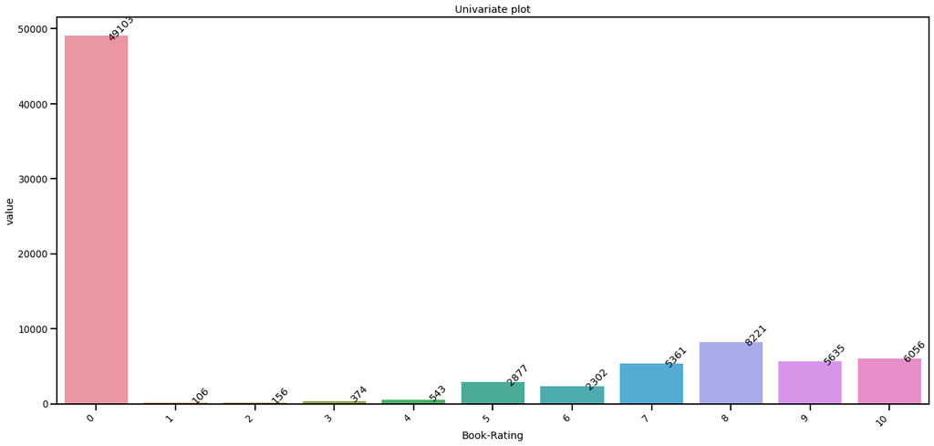

```python
uni_categorical(df_books[['Book-Rating']],'L','Y')
```

We see that as specified by the source: "Ratings (`Book-Rating`) are either explicit, expressed on a scale from 1-10 (higher values denoting higher appreciation), or implicit, expressed by 0."

For this study, it will be used only explicit evaluations.

```python
df_books['Book-Rating'] = df_books['Book-Rating'].astype('int64')
df_books = df_books.loc[df_books['Book-Rating'] > 0]
df_books['Book-Rating'] = df_books['Book-Rating'].astype('category')
```

```
############### Univariate analysis - Categorical ###############

This is univariate analysis for ' Book-Rating '
     Count  Percentage
8    8221       25.99
10   6056       19.15
9    5635       17.81
7    5361       16.95
5    2877        9.10
6    2302        7.28
4     543        1.72
3     374        1.18
2     156        0.49
1     106        0.34
```

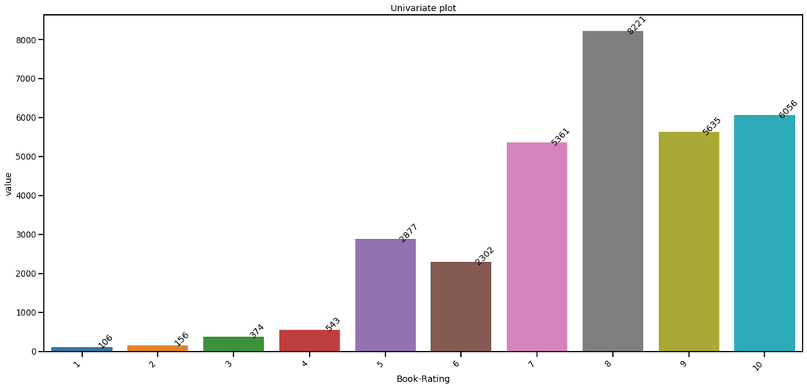

```python
uni_categorical(df_books[['Book-Rating']],'L','Y')
```

We see that most books are well evaluated: more than 6.

```
############### Univariate analysis - Categorical ###############

This is univariate analysis for ' ISBN '
             Count  Percentage
067976402X    256        0.81
0316769487    243        0.77
0345337662    230        0.73
0375727345    229        0.72
0156027321    226        0.71
...           ...         ...
0425043835      1        0.00
0345423461      1        0.00
0394494016      1        0.00
0553247948      1        0.00
0452263123      1        0.00

[5050 rows x 2 columns]
```

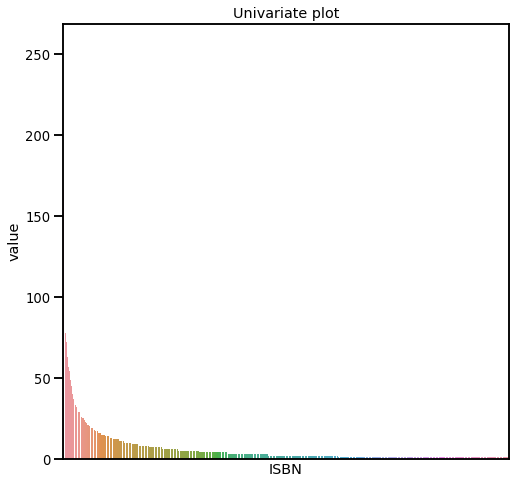

```python
uni_categorical(df_books[['ISBN']])
```

We cannot see nothing wrong with the ISBN, as mentioned in the data source page: " Invalid ISBNs have already been removed from the dataset".

```
############### Univariate analysis - Categorical ###############

This is univariate analysis for ' Book-Title '
                                                     Count  Percentage
Life of Pi                                            336        1.06
Snow Falling on Cedars                                271        0.86
To Kill a Mockingbird                                 267        0.84
The Girls' Guide to Hunting and Fishing               259        0.82
The Catcher in the Rye                                258        0.82
...                                                   ...         ...
Seven Types of Ambiguity                                0        0.00
Selling the Invisible: A Field Guide to Modern ...      0        0.00
Self                                                    0        0.00
Season of Blood: A Rwandan Journey                      0        0.00
god bless the gargoyles                                 0        0.00

[3927 rows x 2 columns]
```

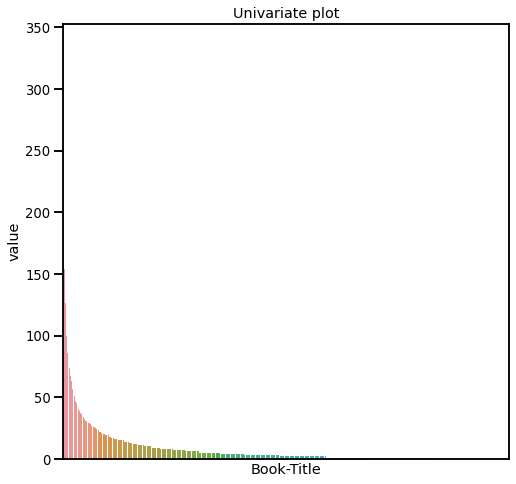

```python
uni_categorical(df_books[['Book-Title']])
```

Book Titles were correctly imported.

```
############### Univariate analysis - Categorical ###############

This is univariate analysis for ' Book-Author '
                     Count  Percentage
Michael Crichton      842        2.66
Maeve Binchy          578        1.83
Barbara Kingsolver    571        1.81
Mary Higgins Clark    564        1.78
Tom Clancy            454        1.44
...                   ...         ...
Denis Johnson           0        0.00
Denise Giardina         0        0.00
Nina Bawden             0        0.00
Dennis Shryack          0        0.00
Octave Mirbeau          0        0.00

[2017 rows x 2 columns]
```

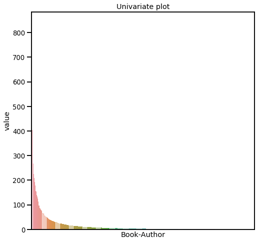

```python
uni_categorical(df_books[['Book-Author']])
```

Book Authors were correctly imported.

```
############### Univariate analysis - Categorical ###############

This is univariate analysis for ' Year-Of-Publication '
       Count  Percentage
2002   2586        8.18
2000   2532        8.00
1999   2450        7.75
2001   2183        6.90
1995   1855        5.86
1996   1803        5.70
1998   1752        5.54
1997   1693        5.35
1991   1432        4.53
2003   1431        4.52
1993   1324        4.19
```

[output cut: 56 more lines]

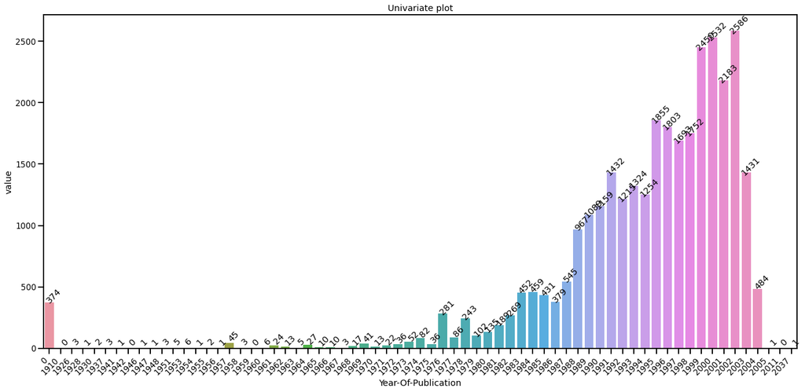

```python
uni_categorical(df_books[['Year-Of-Publication']],'L','Y')
```

We see 1.18% of instances have 0 as Year of Publication.

```
############### Univariate analysis - Categorical ###############

This is univariate analysis for ' Publisher '
                      Count  Percentage
Ballantine Books      2054        6.49
Pocket                1454        4.60
Vintage Books USA     1314        4.15
Bantam Books          1106        3.50
Warner Books          1053        3.33
...                    ...         ...
Liamworks                0        0.00
Learning Links           0        0.00
Lawrence Hill Books      0        0.00
Last Gasp                0        0.00
scholastic               0        0.00

[1025 rows x 2 columns]
```

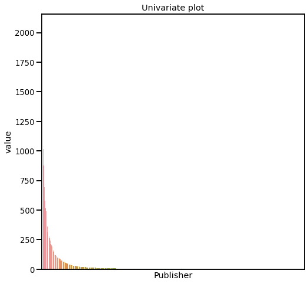

```python
uni_categorical(df_books[['Publisher']])
```

We can see some Publisher's names were not imported correctly as:

- Hodder & Stoughton General Division
- Pan Books in association with Secker & Warburg
- Henry Holt & Company, Inc.
- LÃ?Â¼bbe
- DenoÃ?Â«l
- Le Serpent Ã?Â Plumes
- Hachette Littà©rature

Furthermore, we see that Publishers seemed to be not consolidated.

```
############### Univariate analysis - Categorical ###############

This is univariate analysis for ' series '
                            Count  Percentage
NaN                        20641       65.26
To Kill a Mockingbird        267        0.84
The Vampire Chronicles #1    232        0.73
Jurassic Park #1             201        0.64
Greer Family #1              192        0.61
...                          ...         ...
Silver Brumby #1               0        0.00
Lad #1                         0        0.00
Courtney #1                    0        0.00
Extraordinary Voyages #16      0        0.00
Culture #1                     0        0.00

[1354 rows x 2 columns]
```

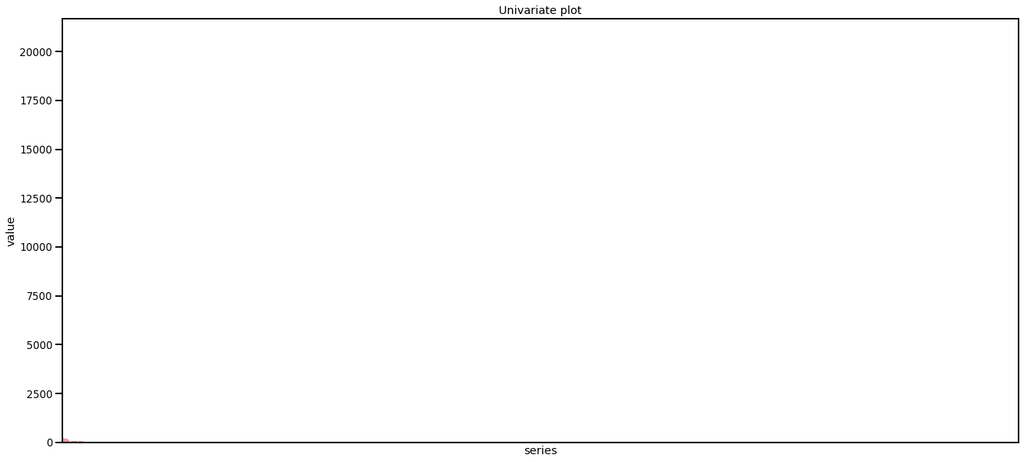

```python
uni_categorical(df_books[['series']],'L')
```

We can see that most of datapoints is not allocated as part of a series (missing values) as expected and together with the Series' name we have the position that the book have in the Series.

```
############### Univariate analysis - Categorical ###############

This is univariate analysis for ' genres '
                                                     Count  Percentage
['Fiction', 'Fantasy', 'Classics', 'Adventure',...    336        1.06
['Fiction', 'Historical Fiction', 'Mystery', 'H...    271        0.86
['Classics', 'Fiction', 'Historical Fiction', '...    267        0.84
['Fiction', 'Chick Lit', 'Short Stories', 'Cont...    259        0.82
['Classics', 'Fiction', 'Young Adult', 'Literat...    258        0.82
...                                                   ...         ...
['Fiction', 'Classics', 'Russia', 'Russian Lite...      0        0.00
['Fiction', 'Classics', 'Romance', 'Historical ...      0        0.00
['Historical Fiction', 'Romance', '18th Century...      0        0.00
['Fiction', 'Classics', 'Poetry', 'Russia', 'Li...      0        0.00
['Historical Fiction', 'Fiction', 'Adventure', ...      0        0.00

[3879 rows x 2 columns]
```

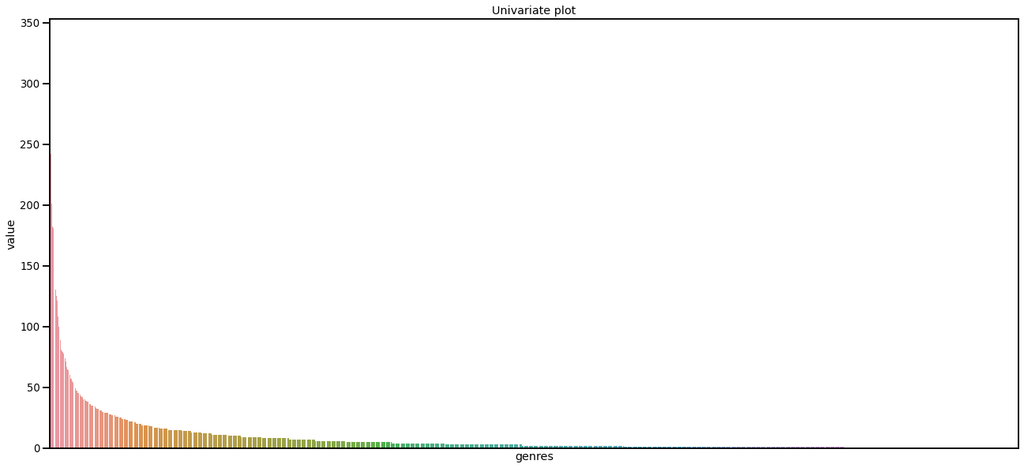

```python
uni_categorical(df_books[['genres']],'L')
```

We see that genres is a list and, as explicited below, it has 10 levels.

```python
df_books['genres'].str.split(',',expand=True).head(5)
```

|  | 0 | 1 | 2 | 3 | 4 | 5 | 6 | 7 | 8 | 9 |
| --- | --- | --- | --- | --- | --- | --- | --- | --- | --- | --- |
| 5 | ['Fiction' | 'Thriller' | 'Mystery' | 'Science Fiction' | 'Suspense' | 'Mystery Thriller' | 'Adventure' | 'Novels' | 'Action' | 'Aviation'] |
| 10 | ['Fiction' | 'Crime' | 'True Crime' | 'Thriller' | 'Mystery' | 'Mystery Thriller' | 'Abuse' | 'New York' | 'Suspense' | 'Drama'] |
| 11 | ['Fiction' | 'Thriller' | 'Mystery' | 'Science Fiction' | 'Suspense' | 'Mystery Thriller' | 'Adventure' | 'Novels' | 'Action' | 'Aviation'] |
| 15 | ['Fiction' | 'Thriller' | 'Suspense' | 'Mystery' | 'Chick Lit' | 'Romance' | 'Contemporary' | 'Drama' | 'Mystery Thriller' | 'Womens Fiction'] |
| 16 | ['Classics' | 'Fiction' | 'Literature' | 'Novels' | 'British Literature' | '20th Century' | 'Feminism' | 'Literary Fiction' | 'School' | 'Modern Classics'] |

```
############### Univariate analysis - Categorical ###############

This is univariate analysis for ' characters '
                                                     Count  Percentage
[]                                                  14105       44.59
['David Sedaris']                                     345        1.09
['Pi Patel', 'Richard Parker']                        336        1.06
['Kabuo Miyamoto', 'Ishmael Chambers', 'Hatsue ...    271        0.86
['Scout Finch', 'Atticus Finch', 'Jem Finch', '...    267        0.84
...                                                   ...         ...
['Sita', 'Seymour Dorsten', 'Ray Riley']                0        0.00
['Joe Sackett', 'Borden Chantry', 'Bess Chantry...      0        0.00
['Joey', 'Albert', 'Sir Nicholls', 'Emily']             0        0.00
['Nicholas Bragg', 'Jane Barclay']                      0        0.00
['Giorgio Viola', "Gian' Battista Fidanza", 'Ch...      0        0.00

[1438 rows x 2 columns]
```

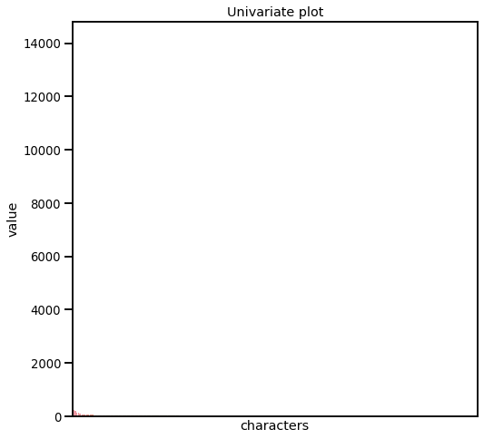

```python
uni_categorical(df_books[['characters']])
```

```
############### Univariate analysis - Categorical ###############

This is univariate analysis for ' setting '
                                   Count  Percentage
[]                                13465       42.57
['United States of America']        857        2.71
['London, England']                 420        1.33
['Dublin (Ireland)']                419        1.32
['California (United States)']      359        1.13
...                                 ...         ...
['Bahrain']                           0        0.00
['Gaze Castle (United Kingdom)']      0        0.00
['Rome (Italy)', 'Italy']             0        0.00
['Discworld', 'The Chalk']            0        0.00
['South Pacific', 'Anopopei']         0        0.00

[806 rows x 2 columns]
```

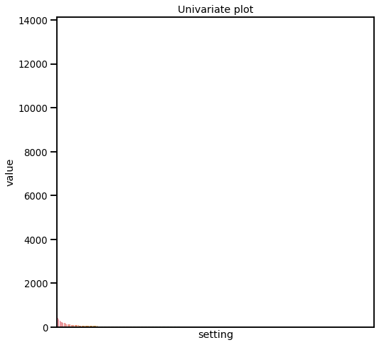

```python
uni_categorical(df_books[['setting']])
```

```
############### Univariate analysis - Categorical ###############

This is univariate analysis for ' firstPublishDate '
           Count  Percentage
NaN        1321        4.18
10/28/99    444        1.40
10/28/93    435        1.38
10/30/00    355        1.12
10/28/98    337        1.07
...         ...         ...
07/30/02      0        0.00
01/01/75      0        0.00
08/01/70      0        0.00
08/01/97      0        0.00
09/27/48      0        0.00

[1599 rows x 2 columns]
```

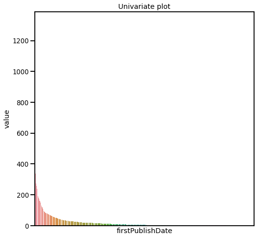

```python
uni_categorical(df_books[['firstPublishDate']])
```

We see diverse set of formats: January 1st 1988 , 1997, and 11/06/73.

```
############### Univariate analysis - Categorical ###############

This is univariate analysis for ' awards '
                                                     Count  Percentage
[]                                                  17677       55.89
['Booker Prize (2002)', 'Bollinger Everyman Wod...    336        1.06
['Anthony Award Nominee for Best First Novel (1...    271        0.86
['Pulitzer Prize for Fiction (1961)', 'Audie Aw...    267        0.84
['Guardian First Book Award Nominee for Longlis...    259        0.82
...                                                   ...         ...
['ECPA Christian Book Award for Biography / Aut...      0        0.00
['Nebula Award Nominee for Novel (1976)', 'Jame...      0        0.00
['Nebula Award Nominee for Novel (1975)']               0        0.00
['Edgar Award Nominee for Best Novel (1979)']           0        0.00
['Booker Prize Nominee (1979)']                         0        0.00

[1253 rows x 2 columns]
```

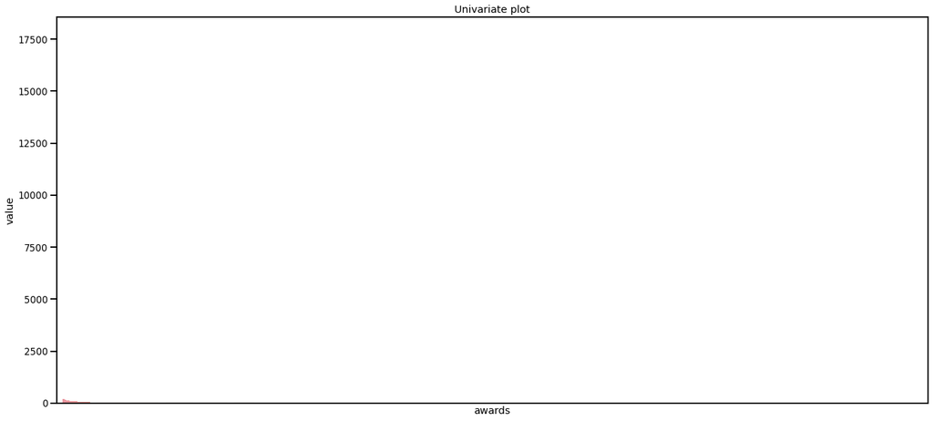

```python
uni_categorical(df_books[['awards']],'L')
```

We see that most datapoints as expected, don't have a award specified. The awards is also of various settings(from its languages).

```
############### Univariate analysis - Categorical ###############

This is univariate analysis for ' User-ID '
         Count  Percentage
11676     472        1.49
23902     106        0.34
98391      93        0.29
153662     78        0.25
95359      76        0.24
...       ...         ...
107972      1        0.00
107980      1        0.00
107994      1        0.00
108016      1        0.00
278846      1        0.00

[14987 rows x 2 columns]
```

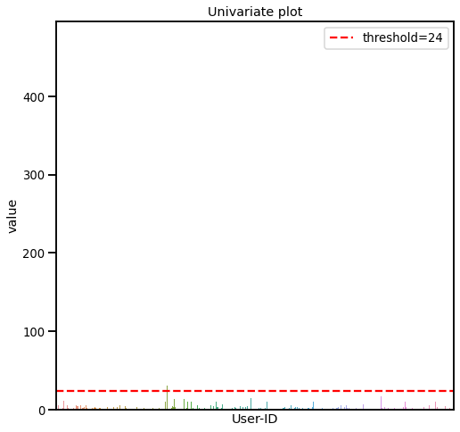

```python
uni_categorical(df_books[['User-ID']].astype('category'),'S','N',24)
```

We can see that only a few of the users have made more than 24 evaluations.

```
############### Univariate analysis - Categorical ###############

This is univariate analysis for ' Location '
                                      Count  Percentage
toronto, ontario, canada               525        1.66
n/a, n/a, n/a                          472        1.49
chicago, illinois, usa                 304        0.96
seattle, washington, usa               289        0.91
london, england, united kingdom        280        0.89
...                                    ...         ...
ringgold, georgia, usa                   0        0.00
franconia, virginia, usa                 0        0.00
ringwood north, victoria, australia      0        0.00
rio de janeiro, na, brazil               0        0.00
london, england,                         0        0.00

[8063 rows x 2 columns]
```

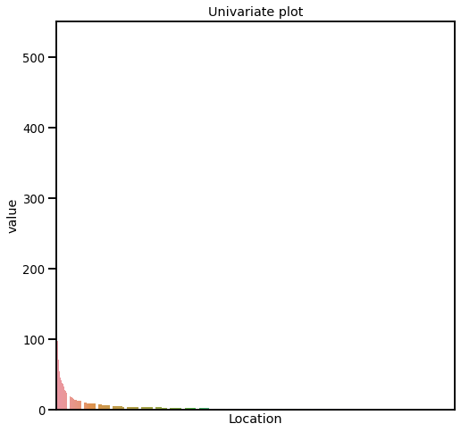

```python
uni_categorical(df_books[['Location']])
```

We can see that the User Location is detailed in different levels as:

- brighton, colorado, usa
- toronto, ,
- n/a, n/a, usa
- iowa city, ,
- tualatin, , ,
- wrightstown, ,
- apo, ae, usa
- ***, illinois, usa
- earth, , universe
- online, n/a, usa
- cambridge, cambridgeshire, united kingdom
- loro ciuffenna fraz. s.giustino v.no, ,

These values show that the users have described their Location as online or earth,universe. Country appears to be the most reliable information, despite having missing values.

#### Looking at numerical features:

```
############### Univariate analysis - Numerical ###############

This is univariate analysis for ' Age '
 count                        21281.0
mean                        36.42794
std                        13.911819
min                              0.0
25%                             27.0
50%                             34.0
75%                             44.0
max                            239.0
variance                   193.53871
IQR                             17.0
range                          239.0
skewness                    2.635699
kurtosis                     25.8589
mode        0    33.0
dtype: float64
Name: Age, dtype: object
```

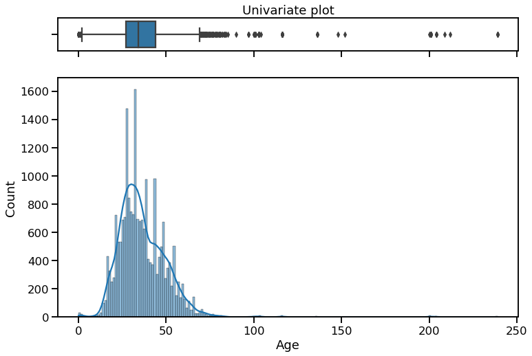

```
Kolmogorov's Statistics=nan, p=nan
Normality's test result: Sample does not look Gaussian (reject H0)
```

```python
uni_numerical(df_books[['Age']])
```

We see some outliers in both sides of the distribution, including what should be some errors: 0 and 239 as age.

```python
#Seetings outpus to 150:
pd.set_option('display.max_rows', 150)
```

# Data Cleaning/Preparation

### Year of Publication and First Date of Publication

I'll try to fill these values as being the First Date of Publication after cleaning this feature to provide only the year. Any remaining missing values will be dropped.

```
############### Univariate analysis - Categorical ###############

This is univariate analysis for ' Year-Of-Publication '
       Count  Percentage
2002   2586        8.18
2000   2532        8.00
1999   2450        7.75
2001   2183        6.90
1995   1855        5.86
1996   1803        5.70
1998   1752        5.54
1997   1693        5.35
1991   1432        4.53
2003   1431        4.52
1993   1324        4.19
```

[output cut: 56 more lines]

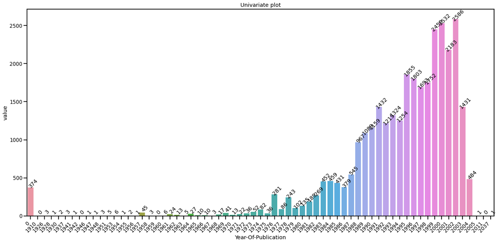

```python
uni_categorical(df_books[['Year-Of-Publication']],'L','Y')
```

```python
# Extracting Year from Publisher Date
df_books['firstPublishDate'] = df_books['firstPublishDate'].str.extract(r'(\d{4}|\d{2}$)').astype(pd.StringDtype())

# Converting 2 digits year to 4 digits, 00 and 01 will be interpreted as 2000 and 2001
df_books['firstPublishDate'] = df_books['firstPublishDate'].replace(r'^01$','2001',regex=True)
df_books['firstPublishDate'] = df_books['firstPublishDate'].replace(r'^00$','2000',regex=True)
df_books['firstPublishDate'] = df_books['firstPublishDate'].replace(r'^00$','2000',regex=True)
df_books['firstPublishDate'] = df_books['firstPublishDate'].apply(lambda x: ('19' + str(x)) if (len(str(x)) == 2) else  x )

# Filling Year of Publication with FIrst Publisher Date if 0
df_books['Year-Of-Publication'] = np.where(df_books['Year-Of-Publication']==0,df_books['firstPublishDate'],df_books['Year-Of-Publication'])
```

```python
# Dropping instances with Year-Of-Publication that has received null as values
res = sum(df_books['Year-Of-Publication'].isnull())

print('There are', res , 'missing values in "Year-Of-Publication". ' )
df_books = df_books[df_books['Year-Of-Publication'].notna()]
if res != 0 :
    print('Misssing values were dropped.')
```

```
There are 2 missing values in "Year-Of-Publication".
Misssing values were dropped.
```

```
############### Univariate analysis - Categorical ###############

This is univariate analysis for ' Year-Of-Publication '
       Count  Percentage
2002   2586        8.18
2000   2535        8.01
1999   2458        7.77
2001   2184        6.91
1995   1855        5.86
1996   1836        5.80
1998   1781        5.63
1997   1711        5.41
1991   1435        4.54
2003   1431        4.52
1993   1342        4.24
```

[output cut: 61 more lines]

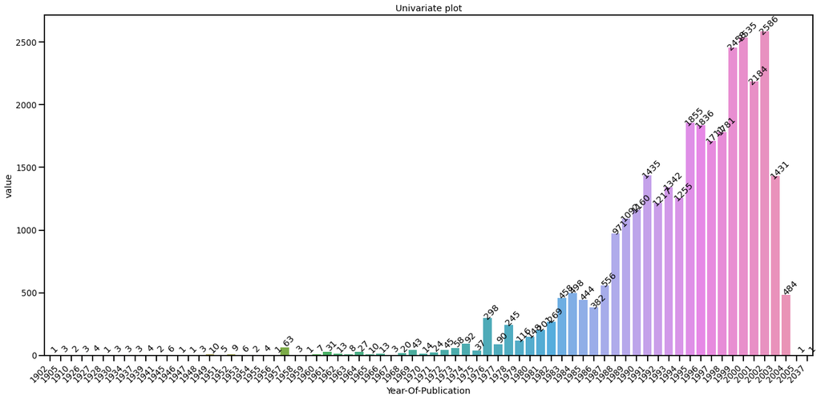

```python
df_books['Year-Of-Publication'] = df_books['Year-Of-Publication'].astype('int64').astype('category')
df_books.sort_values(by=['Year-Of-Publication'], ascending=True,inplace=True)

uni_categorical(df_books[['Year-Of-Publication']],'L','Y')
```

The original dataset was created in August/September 2004, which turns Year of Publication after this an error. These instances will be dropped.

We also see that there are few books evaluated with the year of Publication before 1985, these will be consolidated to a new category:

```
- '< 1985'
```

```python
bef = df_books.shape[0]
df_books['Year-Of-Publication'] = df_books['Year-Of-Publication'].astype('int64')
df_books = df_books.loc[df_books['Year-Of-Publication'] <= 2004]

print(bef - df_books.shape[0],'instances were dropped.')

# new category
df_books['Year-Of-Publication'] = np.where(df_books['Year-Of-Publication'] < 1985,'Before 1985',df_books['Year-Of-Publication'])

df_books['Year-Of-Publication'] = df_books['Year-Of-Publication'].astype('category')
df_books['Year-Of-Publication'] = pd.Categorical(df_books['Year-Of-Publication'],
                      categories=['Before 1985','1985','1986','1987','1988','1989','1990','1991','1992','1993','1994','1995','1996','1997','1998','1999','2000','2001','2002','2003','2004'],
                      ordered=True)
```

```
2 instances were dropped.
```

```
############### Univariate analysis - Categorical ###############

This is univariate analysis for ' Year-Of-Publication '
              Count  Percentage
Before 1985   2912        9.21
2002          2586        8.18
2000          2535        8.02
1999          2458        7.77
2001          2184        6.91
1995          1855        5.87
1996          1836        5.81
1998          1781        5.63
1997          1711        5.41
1991          1435        4.54
2003          1431        4.52
1993          1342        4.24
1994          1255        3.97
1992          1217        3.85
1990          1160        3.67
1989          1092        3.45
1988           971        3.07
1987           556        1.76
2004           484        1.53
1985           444        1.40
1986           382        1.21
```

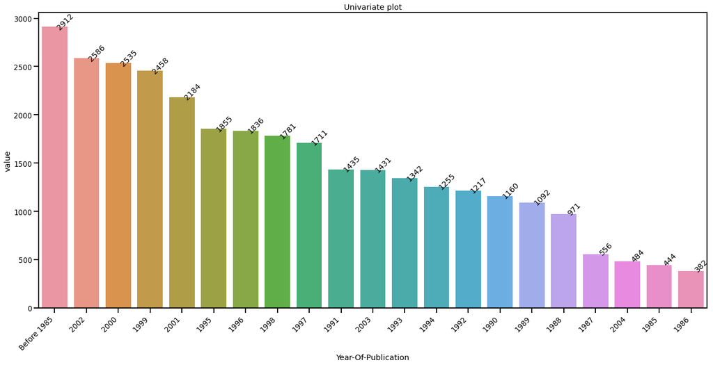

```python
uni_categorical(df_books[['Year-Of-Publication']],'L','Y')
```

First publish data will be categorized as:

```
- Unknown for zeros/missing values
- Boomers and Earlier (<1981)
- Millenium Era (<1996)
- Gen Z and after
```

Source: https://www.beresfordresearch.com/age-range-by-generation/

```
############### Univariate analysis - Categorical ###############

This is univariate analysis for ' firstPublishDate '
       Count  Percentage
1999   1809        5.72
2001   1808        5.72
2000   1729        5.47
1998   1658        5.24
0      1319        4.17
1997   1296        4.10
1994   1242        3.93
1996   1204        3.81
1995   1164        3.68
1992   1037        3.28
1993    995        3.15
```

[output cut: 94 more lines]

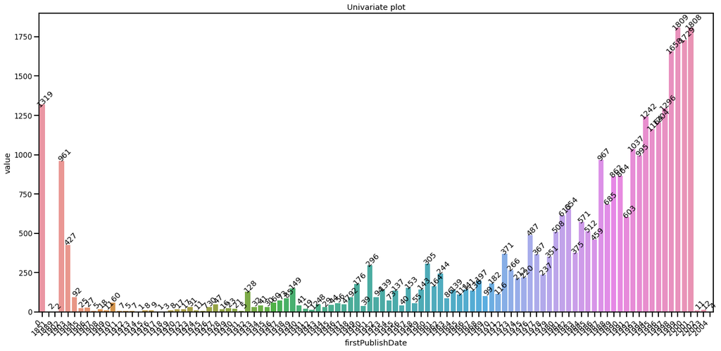

```python
df_books['firstPublishDate'].fillna(0,inplace=True)
df_books['firstPublishDate'] = df_books['firstPublishDate'].astype('int64')
df_books.sort_values(by=['firstPublishDate'], ascending=True,inplace=True)
df_books['firstPublishDate'] = df_books['firstPublishDate'].astype('category')
uni_categorical(df_books[['firstPublishDate']],'L','Y')
```

```python
# new categories
df_books['firstPublishDate'] = df_books['firstPublishDate'].astype('int64')
df_books['firstPublishDate'] = np.where(df_books['firstPublishDate']==0,
                                        'Unknown',
                                        np.where(df_books['firstPublishDate'] < 1981,
                                        'Boomers and Earlier (<1981)',
                                                 np.where(df_books['firstPublishDate'] < 1996,
                                        'Millenium Era (1981 to 1996)',
                                        'Gen Z and after (> 1997)')))
df_books['firstPublishDate'] = df_books['firstPublishDate'].astype('category')

df_books['firstPublishDate'] = pd.Categorical(df_books['firstPublishDate'],
                      categories=['Unknown','Boomers and Earlier (<1981)','Millenium Era (1981 to 1996)','Gen Z and after (> 1997)'],
                      ordered=True)
```

```
############### Univariate analysis - Categorical ###############

This is univariate analysis for ' firstPublishDate '
                               Count  Percentage
Millenium Era (1981 to 1996)  11603       36.69
Gen Z and after (> 1997)       9531       30.14
Boomers and Earlier (<1981)    9174       29.01
Unknown                        1319        4.17
```

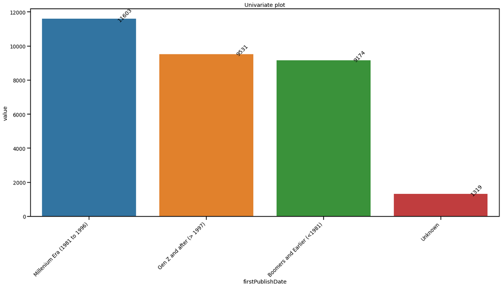

```python
uni_categorical(df_books[['firstPublishDate']],'L','Y')
```

### Publisher

We could see some Publisher's names were not imported correctly as:

- Hodder & Stoughton General Division
- Pan Books in association with Secker & Warburg
- Henry Holt & Company, Inc.
- LÃ?Â¼bbe
- DenoÃ?Â«l, left as it is:https://www.sapnaonline.com/shop/publisher/deno%C3%A3%C2%A3%C3%A2%C2%ABl
- PiratfÃ¶rlaget, changed accordingly: https://www.abebooks.com/book-search/title/v%E3%A4gens-slut/
- Le Serpent Ã?Â Plumes
- Hachette Littà©rature

```python
# Source: https://www.i18nqa.com/debug/utf8-debug.html
df_books['Publisher'] = df_books['Publisher'].str.replace('&amp;','&',regex=False)
df_books['Publisher'] = df_books['Publisher'].str.replace('Ã?Â¼','ü',regex=False)
df_books['Publisher'] = df_books['Publisher'].str.replace('Ã?Â','à',regex=False)
df_books['Publisher'] = df_books['Publisher'].str.replace('PiratfÃ¶rlaget','PiratfÃ rlage',regex=False)
df_books['Publisher'] = df_books['Publisher'].str.replace('à©','é',regex=False)

df_books['Publisher'].value_counts()
```

```
Ballantine Books                     2054
Pocket                               1454
Vintage Books USA                    1314
Bantam Books                         1106
Warner Books                         1053
                                     ...
Duke Univ Pr                            1
The Penguin Press                       1
Scholasstic, Inc                        1
Addison Wesley Publishing Company       1
University of Washington Press          1
Name: Publisher, Length: 808, dtype: int64
```

There's many publishers with only 1 book. This feature will be dropped.

```python
df_books.drop('Publisher',axis=1,inplace=True)
```

### Series

It'll be renamed to Series and turned into a boolean feature: it is part of a series or not?

```python
#Renaming column
df_books.rename(columns={'series': 'Series'},inplace=True)

# Transforming feature
df_books['Series'] = df_books['Series'].apply(lambda x: 'Y' if x != '' else  'N' )
df_books['Series'].fillna('N',inplace=True)
```

```
############### Univariate analysis - Categorical ###############

This is univariate analysis for ' Series '
    Count  Percentage
N  20638       65.25
Y  10989       34.75
```

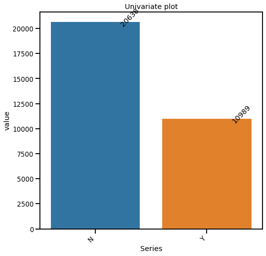

```python
uni_categorical(df_books[['Series']],'S','Y')
```

We can see that a little more than 1/3 of data points belongs to a series

### Genres

Looking at the distribution of Genres levels:

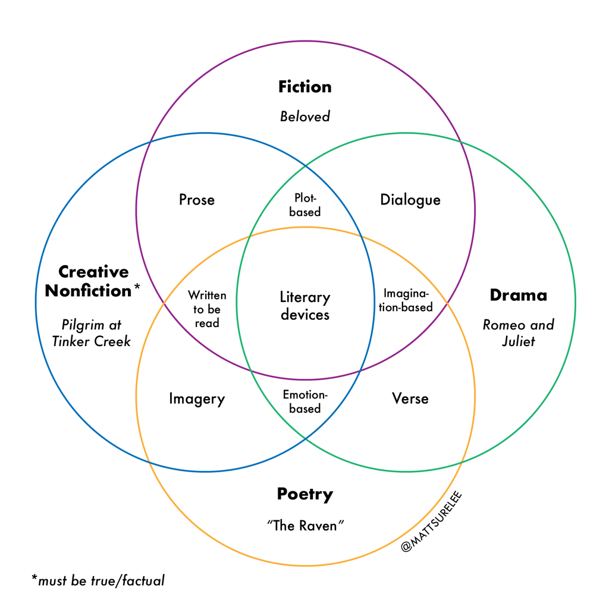

Source: https://human.libretexts.org/Bookshelves/Literature_and_Literacy/Writing_and_Critical_Thinking_Through_Literature_(Ringo_and_Kashyap)/01%3A_Introduction/1.8%3A_The_Literary_Landscape%3A_Four_Major_Genres